# KIDM - Marketing - Datensatz

Alexander Hilberer

## Klassifikationsverfahren im DataMining

Dies sind die Packete, welche für dieses Projekt verwendet wurden.

```r
library(gridExtra)
library(Hmisc)
library(PRROC)
library(MLmetrics)
library(ROCR)
library(ggplot2)
library(e1071)
library(caret)
library(mice)
library(randomForest)
library(corrplot)
library(dplyr)
library(VIM)
library(glmnet)
library(DMwR)
library(tidymodels)
library(tidyverse)
```

## Einlesen der Datensätze

Im folgenden wird zunächst nur der “marketing_dataset.csv”, abgespeichert unter der Variable “df” Verwendet.

```r
df = read.csv("C:/Users/Alexander/OneDrive - hochschule-trier.de/uni/4. Semester/KIDM/Projekt/Marketing/marketing_dataset.csv",sep="#",dec=",")[,2:17]

df_Dont_use = read.csv("C:/Users/Alexander/OneDrive - hochschule-trier.de/uni/4. Semester/KIDM/Projekt/Marketing/marketing_dataset_to_predict.csv",sep="§",dec=",",fileEncoding = "UTF-8")[,2:17]
```

Nachdem der Datensatz erfolgreich eigelesen wurde verschaffen wir uns einen überblick über die Daten:

```r
summary(df)
```

```
##       age                  job           marital          education
##  Min.   : 18.00   blue-collar:6764           :   98   primary  : 4733
##  1st Qu.: 33.00   management :6576   divorced: 3643   secondary:16246
##  Median : 39.00   technician :5382   married :18960   tertiary : 9380
##  Mean   : 40.98   admin.     :3563   single  : 8947   unknown  : 1289
##  3rd Qu.: 48.00   services   :2911
##  Max.   :196.00   retired    :1585
##  NA's   :3287     (Other)    :4867
##  default        balance       housing      loan            contact
##  no :31061   Min.   : -8019      :   98   no :26539   cellular :20547
##  yes:  587   1st Qu.:    71   no :14108   yes: 5109   telephone: 1988
##              Median :   446   yes:17442               unknown  : 9113
##              Mean   :  1362
##              3rd Qu.:  1425
##              Max.   :102127
##              NA's   :98
##       day            month         campaign          pdays
##  Min.   : 1.00   may    :9692   Min.   : 1.000   Min.   : -1.00
##  1st Qu.: 8.00   jul    :4833   1st Qu.: 1.000   1st Qu.: -1.00
##  Median :16.00   aug    :4411   Median : 2.000   Median : -1.00
##  Mean   :15.79   jun    :3701   Mean   : 2.766   Mean   : 40.53
##  3rd Qu.:21.00   nov    :2811   3rd Qu.: 3.000   3rd Qu.: -1.00
##  Max.   :32.00   apr    :2041   Max.   :63.000   Max.   :871.00
##                  (Other):4159   NA's   :98       NA's   :98
##     previous          poutcome       y
##  Min.   :  0.000   failure: 3471   no :27942
##  1st Qu.:  0.000   other  : 1281   yes: 3706
##  Median :  0.000   success: 1051
##  Mean   :  0.584   unknown:25845
##  3rd Qu.:  0.000
##  Max.   :275.000
##
```

```r
str(df)
```

```
## 'data.frame':    31648 obs. of  16 variables:
##  $ age      : num  55 37 31 29 55 56 40 43 45 26 ...
##  $ job      : Factor w/ 13 levels "","admin.","blue-collar",..: 6 6 6 2 6 7 2 6 6 10 ...
##  $ marital  : Factor w/ 4 levels "","divorced",..: 3 3 4 4 2 3 4 4 3 4 ...
##  $ education: Factor w/ 4 levels "primary","secondary",..: 3 3 3 2 3 1 2 2 3 2 ...
##  $ default  : Factor w/ 2 levels "no","yes": 1 1 1 1 1 2 1 1 1 1 ...
##  $ balance  : num  2960 4842 1598 65 -207 ...
##  $ housing  : Factor w/ 3 levels "","no","yes": 3 3 3 3 2 2 3 3 2 2 ...
##  $ loan     : Factor w/ 2 levels "no","yes": 1 1 1 1 1 2 1 1 1 1 ...
##  $ contact  : Factor w/ 3 levels "cellular","telephone",..: 1 1 1 1 1 1 1 3 2 1 ...
##  $ day      : int  31 25 7 14 2 28 20 27 3 9 ...
##  $ month    : Factor w/ 12 levels "apr","aug","dec",..: 2 10 6 9 4 2 1 9 4 1 ...
##  $ campaign : num  1 1 33 6 1 3 2 3 2 6 ...
##  $ pdays    : num  98 -1 -1 -1 -1 -1 -1 -1 -1 -1 ...
##  $ previous : int  11 0 0 0 0 0 0 0 0 0 ...
##  $ poutcome : Factor w/ 4 levels "failure","other",..: 2 4 4 4 4 4 4 4 4 4 ...
##  $ y        : Factor w/ 2 levels "no","yes": 1 1 1 1 1 1 1 1 1 1 ...
```

Wie wir sehen können, enthalten einige Variablen einen leerstring, diese Daten sind “NA-Werte”, welche noch nicht dem Datentyp NA zugeordnet sind. Dies wird im folgenden behoben.

```r
df[df==""] = NA #Leerstrings mit NA ersetzen
df$marital = factor(df$marital) #entfernen des leeren levels
df$housing = factor(df$housing) #entfernen des leeren levels

df$age = as.integer(df$age) #Umformatierung in Numeric
df$age = abs(df$age) #Negatives Alter kann nicht existieren

df$balance = as.integer(df$balance) #Umformatierung in Numeric
df$balance = abs(df$balance) #Negatives verfügbares einkommen ist unrealistisch

df$campaign = as.integer(df$campaign) #Umformatierung in Numeric
df$campaign = abs(df$campaign) #Man keinen einen Kunden nicht negativ oft kontaktieren.

df$pdays = as.numeric(df$pdays) #Umformatierung in Numeric

df$previous = as.integer(df$previous) #Umformatierung in Numeric
df$previous = abs(df$previous) #Man keinen einen Kunden nicht negativ oft kontaktieren.

df$day = as.factor(df$day) #Ein Monat kann nur bis zu 31 Tage haben, demzufolge ist ein Factor am Sinnfollsten.

df$y = factor(df$y, levels = c("yes","no"))
summary(df)
```

```
##       age                  job           marital          education
##  Min.   : 18.00   blue-collar:6764   divorced: 3643   primary  : 4733
##  1st Qu.: 33.00   management :6576   married :18960   secondary:16246
##  Median : 39.00   technician :5382   single  : 8947   tertiary : 9380
##  Mean   : 40.98   admin.     :3563   NA's    :   98   unknown  : 1289
##  3rd Qu.: 48.00   services   :2911
##  Max.   :196.00   (Other)    :6354
##  NA's   :3287     NA's       :  98
##  default        balance       housing       loan            contact
##  no :31061   Min.   :     0   no  :14108   no :26539   cellular :20547
##  yes:  587   1st Qu.:   134   yes :17442   yes: 5109   telephone: 1988
##              Median :   483   NA's:   98               unknown  : 9113
##              Mean   :  1414
##              3rd Qu.:  1433
##              Max.   :102127
##              NA's   :98
##       day            month         campaign          pdays
##  20     : 1935   may    :9692   Min.   : 1.000   Min.   : -1.00
##  18     : 1631   jul    :4833   1st Qu.: 1.000   1st Qu.: -1.00
##  21     : 1449   aug    :4411   Median : 2.000   Median : -1.00
##  6      : 1378   jun    :3701   Mean   : 2.766   Mean   : 40.53
##  5      : 1361   nov    :2811   3rd Qu.: 3.000   3rd Qu.: -1.00
##  17     : 1351   apr    :2041   Max.   :63.000   Max.   :871.00
##  (Other):22543   (Other):4159   NA's   :98       NA's   :98
##     previous          poutcome       y
##  Min.   :  0.000   failure: 3471   yes: 3706
##  1st Qu.:  0.000   other  : 1281   no :27942
##  Median :  0.000   success: 1051
##  Mean   :  0.584   unknown:25845
##  3rd Qu.:  0.000
##  Max.   :275.000
##
```

```r
str(df)
```

```
## 'data.frame':    31648 obs. of  16 variables:
##  $ age      : int  55 37 31 29 55 56 40 43 45 26 ...
##  $ job      : Factor w/ 13 levels "","admin.","blue-collar",..: 6 6 6 2 6 7 2 6 6 10 ...
##  $ marital  : Factor w/ 3 levels "divorced","married",..: 2 2 3 3 1 2 3 3 2 3 ...
##  $ education: Factor w/ 4 levels "primary","secondary",..: 3 3 3 2 3 1 2 2 3 2 ...
##  $ default  : Factor w/ 2 levels "no","yes": 1 1 1 1 1 2 1 1 1 1 ...
##  $ balance  : int  2960 4842 1598 65 207 123 2360 109 1199 766 ...
##  $ housing  : Factor w/ 2 levels "no","yes": 2 2 2 2 1 1 2 2 1 1 ...
##  $ loan     : Factor w/ 2 levels "no","yes": 1 1 1 1 1 2 1 1 1 1 ...
##  $ contact  : Factor w/ 3 levels "cellular","telephone",..: 1 1 1 1 1 1 1 3 2 1 ...
##  $ day      : Factor w/ 32 levels "1","2","3","4",..: 31 25 7 14 2 28 20 27 3 9 ...
##  $ month    : Factor w/ 12 levels "apr","aug","dec",..: 2 10 6 9 4 2 1 9 4 1 ...
##  $ campaign : int  1 1 33 6 1 3 2 3 2 6 ...
##  $ pdays    : num  98 -1 -1 -1 -1 -1 -1 -1 -1 -1 ...
##  $ previous : int  11 0 0 0 0 0 0 0 0 0 ...
##  $ poutcome : Factor w/ 4 levels "failure","other",..: 2 4 4 4 4 4 4 4 4 4 ...
##  $ y        : Factor w/ 2 levels "yes","no": 2 2 2 2 2 2 2 2 2 2 ...
```

## Grafische Analyse: Kategoriale Variablen (Factor)

Nachdem wir nun die Datentypen richtig zugeordnet haben, sowie eine erste kleine Analyse durchgeführt haben können wir in eine tiefere analyse des Datensatzes übergehen.

### y-Variable (Zielvariable)

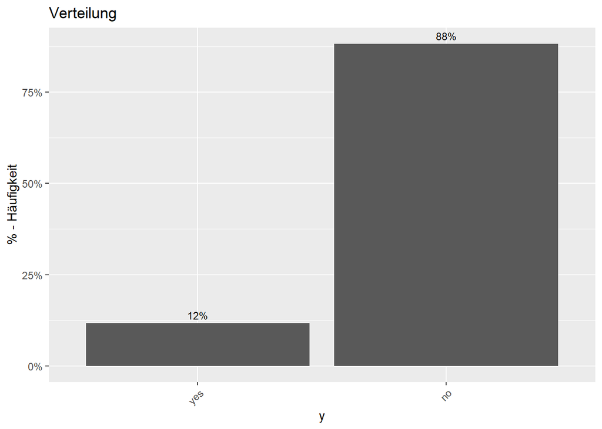

Wie man sieht ist die Zielvariable sehr ungleich Verteilt und muss dementsprechend beim Training des Models entsprechend verteilt werden.

### Job-Variable

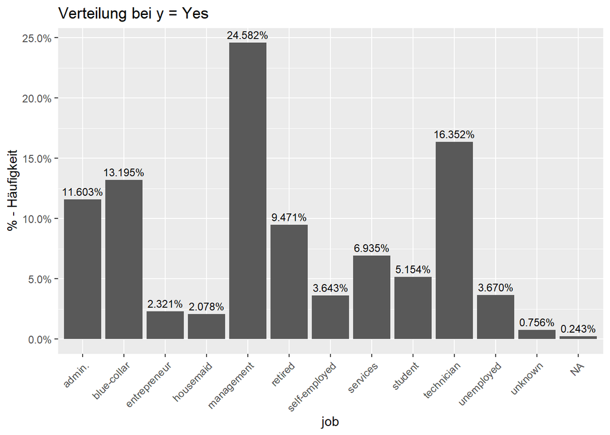

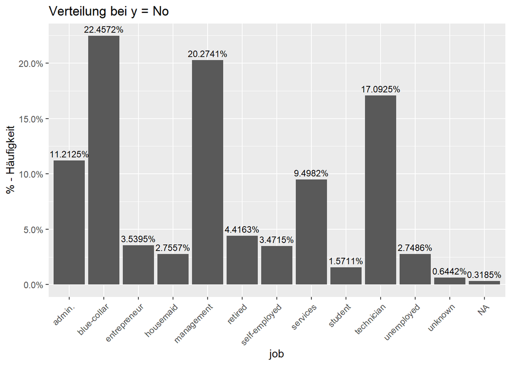

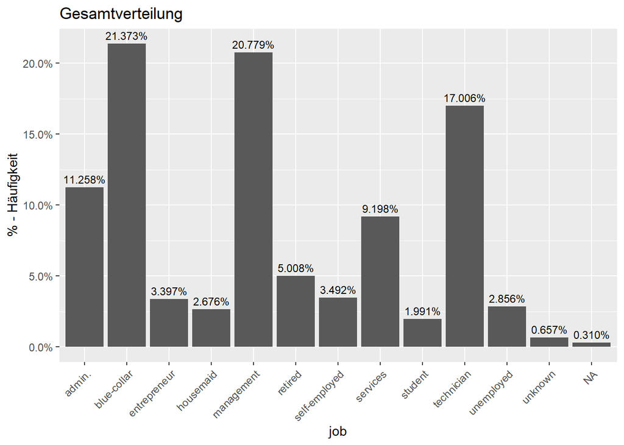

Wir können sehen, dass wir sowohl werte als “NA” als auch als “unknown” klassifiziert haben. Die Aussagekraft der beiden Variablen jedoch ist die selbe, desshalb werden wir im folgenden die “unknown” Variable NA setzen.

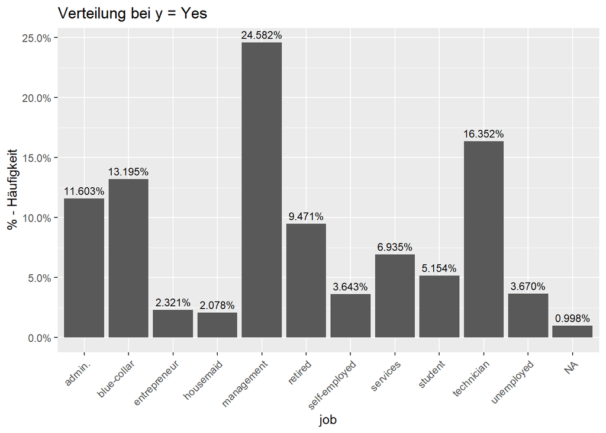

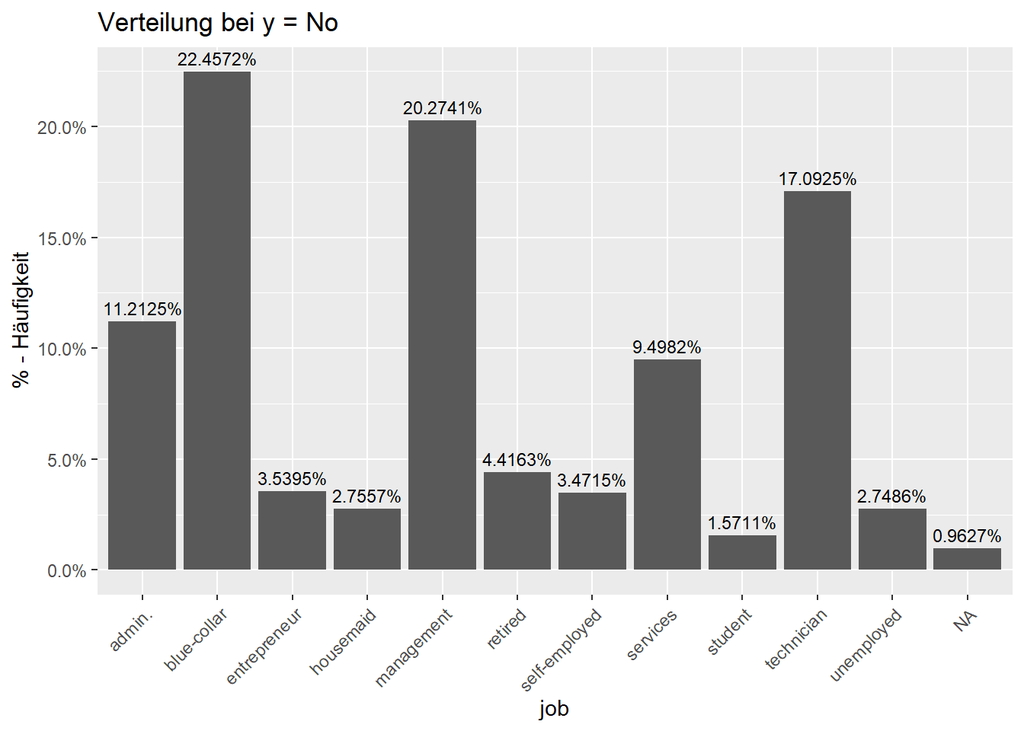

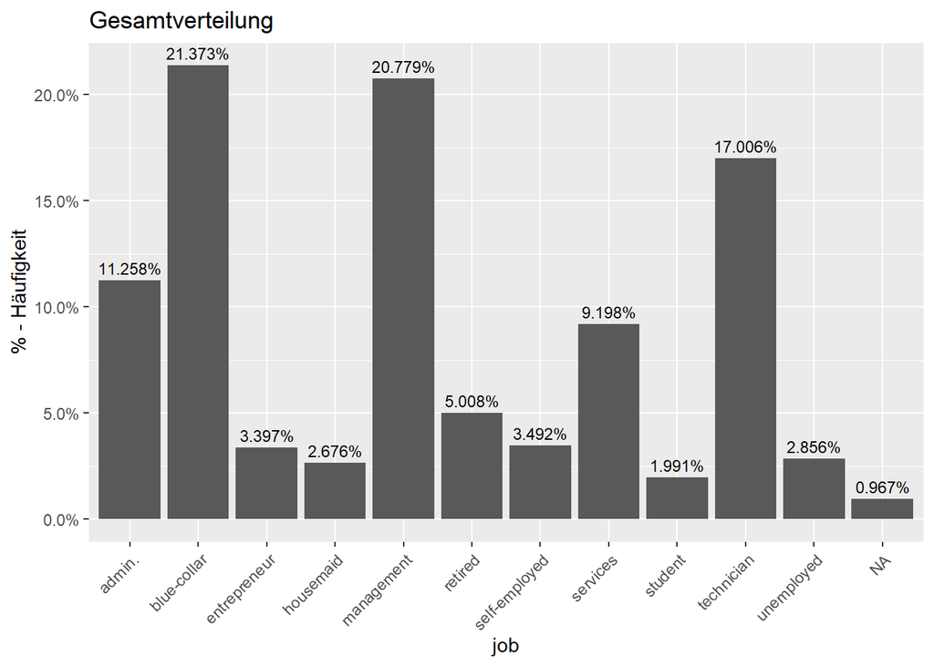

Der NA-Anteil ist verschwindend gering deshalb sollte eine Imputation von Werten später kein Problem darstellen.

### Marital-Variable

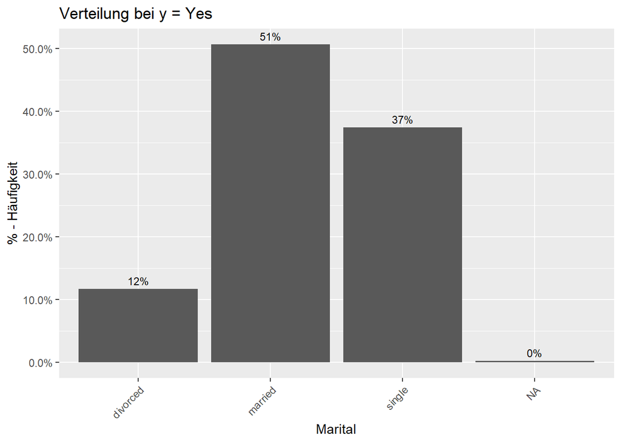

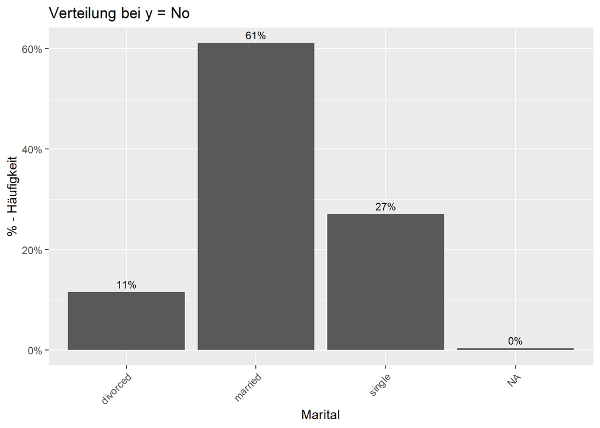

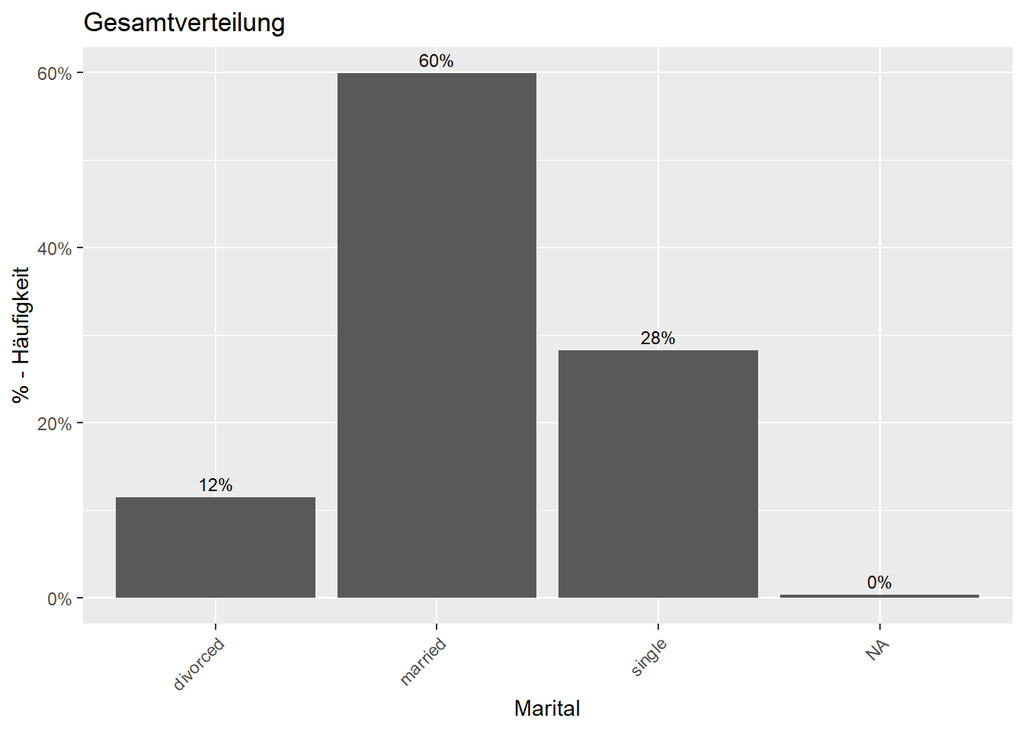

### Education-Variable

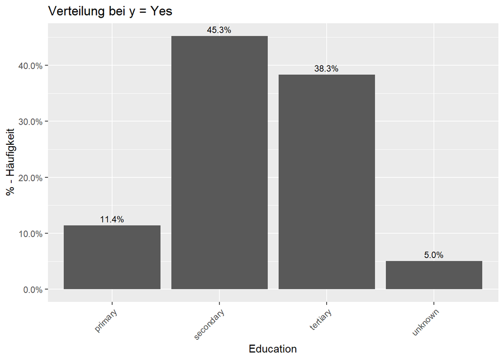

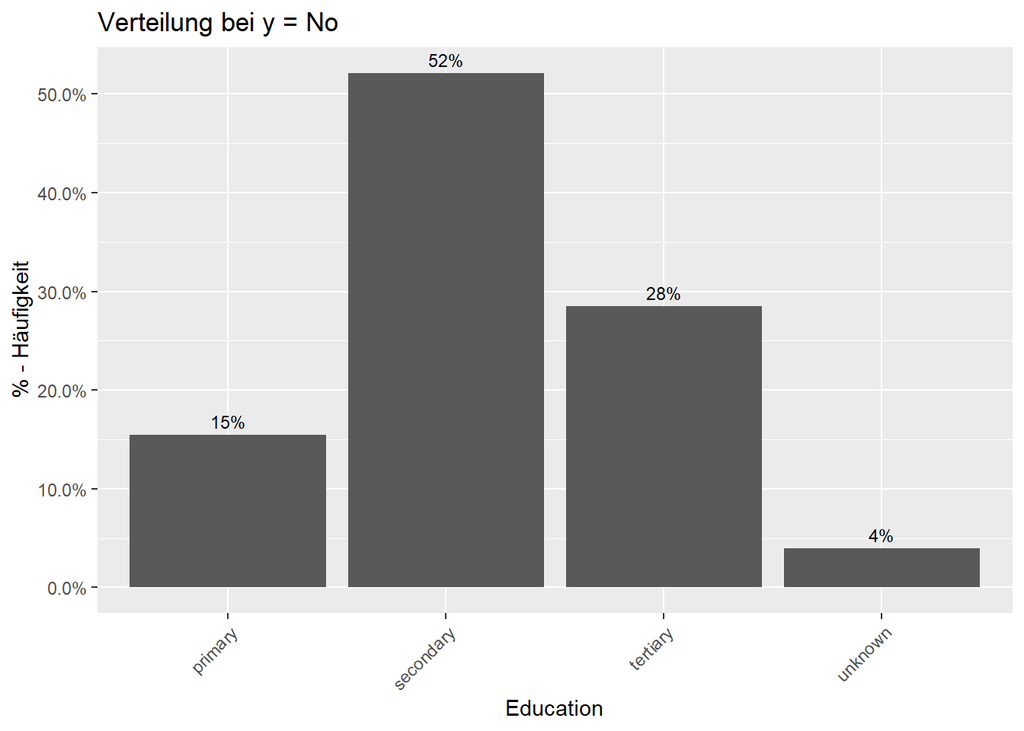

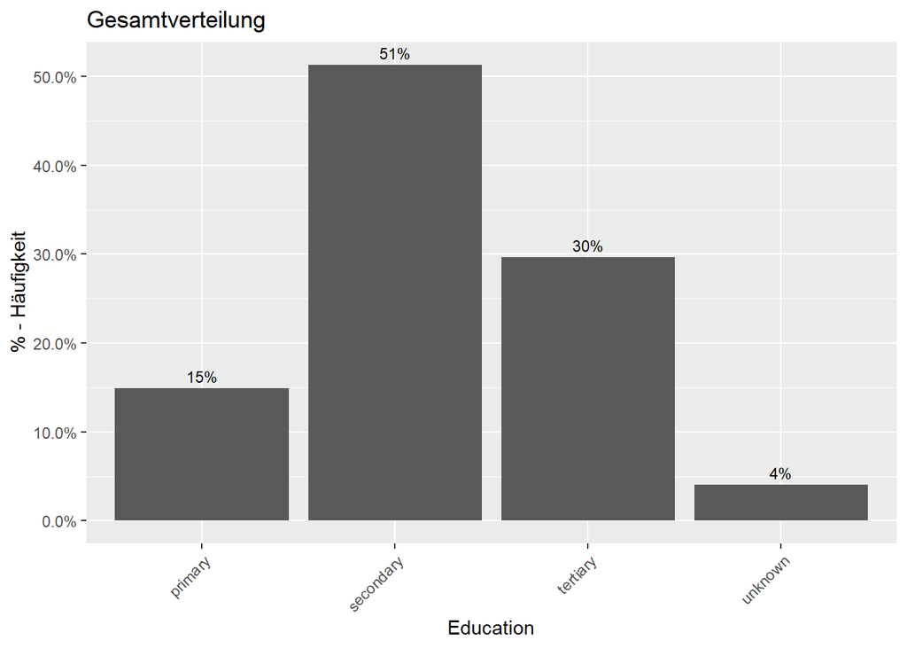

Wie wir sehen, gibt es hier auch noch eine “unknown” Varibale, wir setzen diese NA.

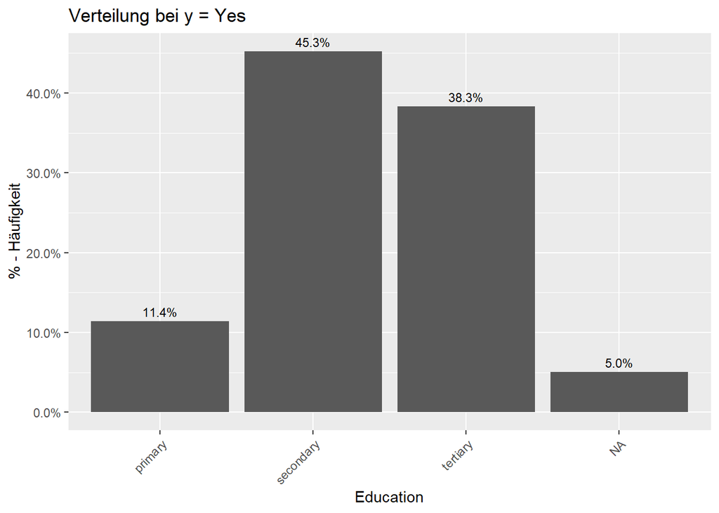

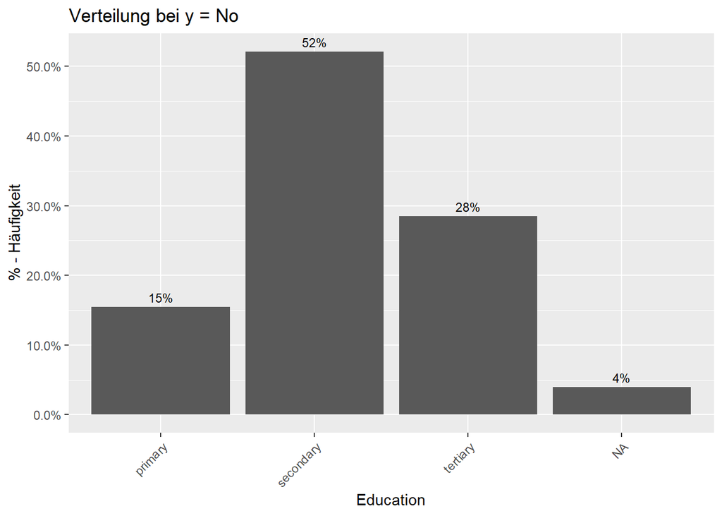

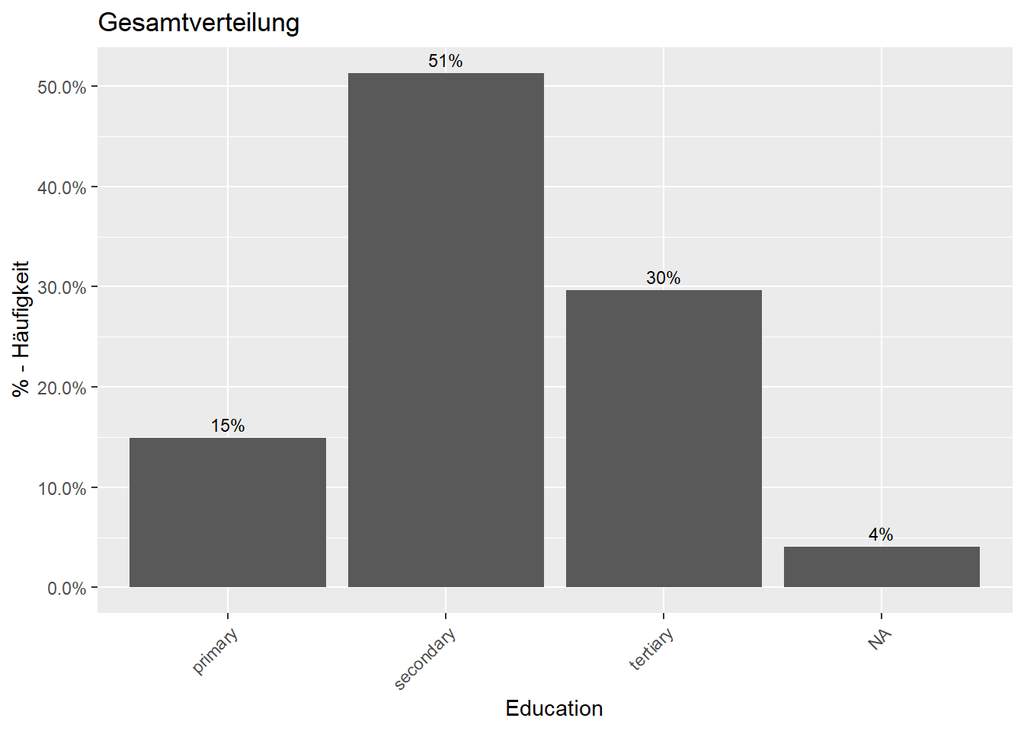

Der NA-Anteil ist auch hier relativ gering und sollte später kein Problem für die Imputation darstellen.

### Default-Variable

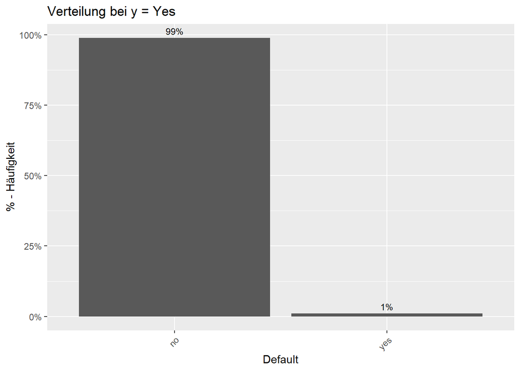

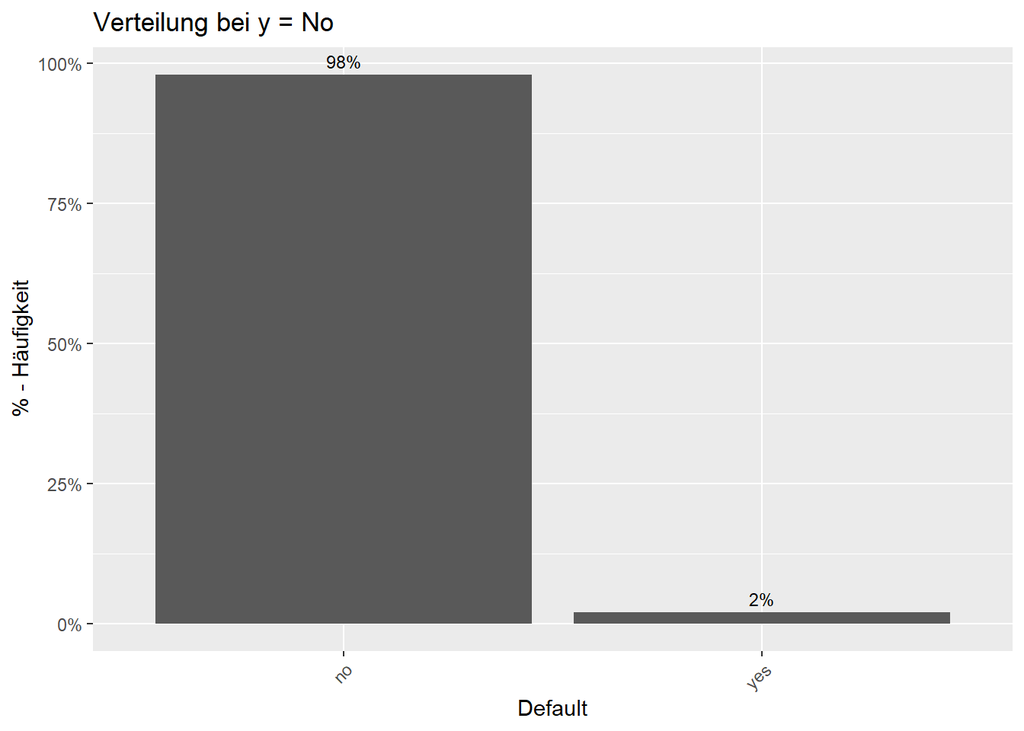

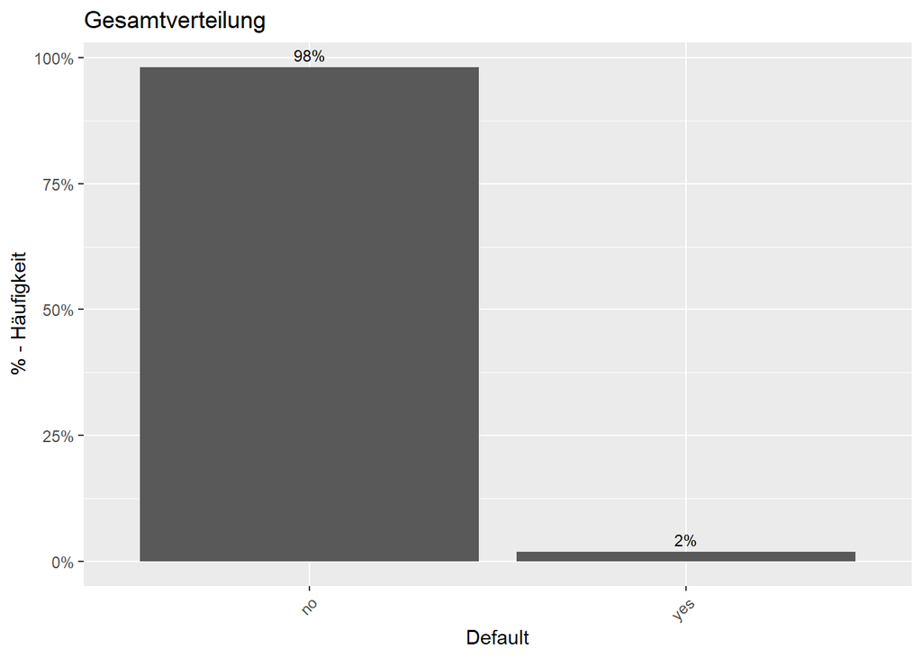

Viele Kunden haben keinen Kredit, die Vertielung nach der Zielvariablen hier ist jedoch sehr ähnlich.

### Housing-Variable

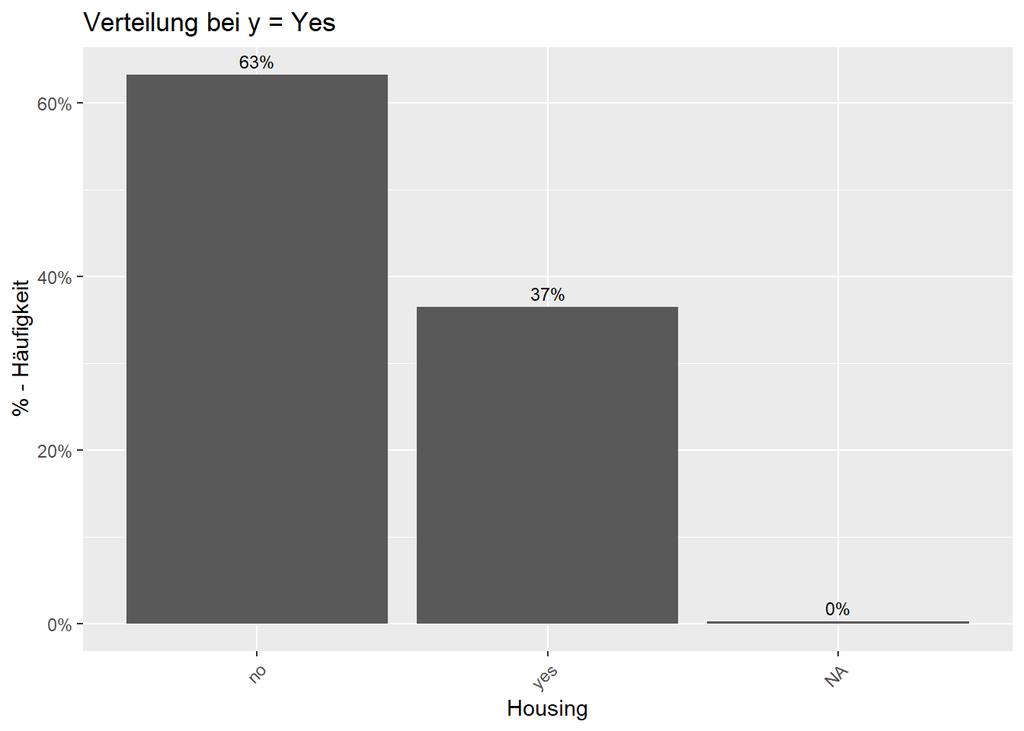

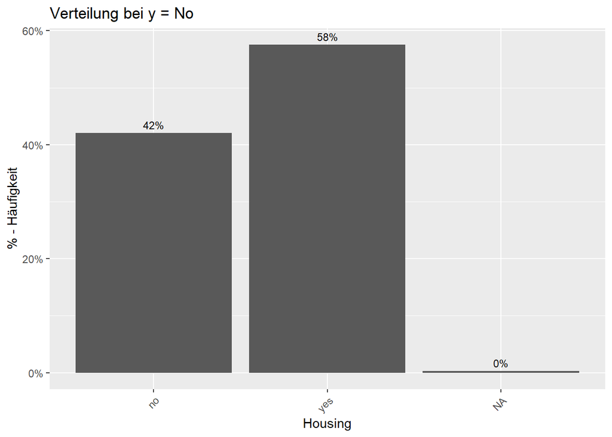

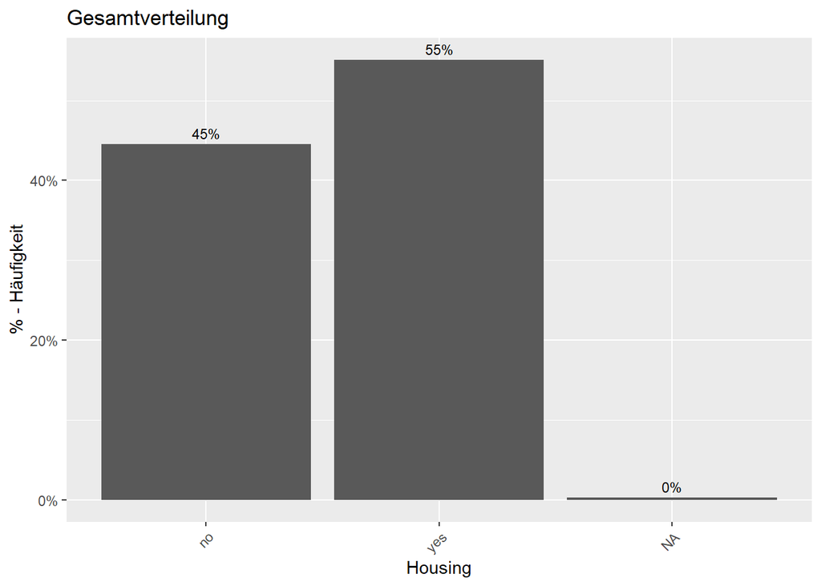

Sollte die Person bereits ein Hausdarlehnen haben, so ist es deutlich wahrscheinlicher, dass sie kein weiteres Darlehenen aufnehmen wird. Desweiteren ist der NA-Anteil gering (unter 1%).

### Loan-Variable

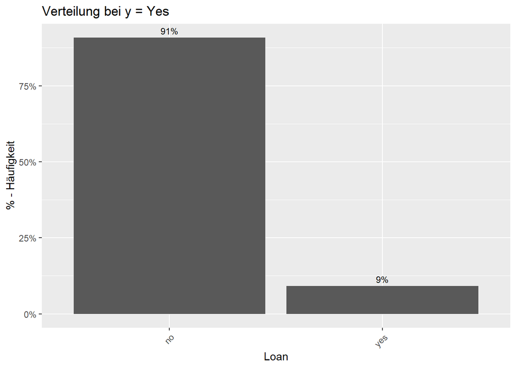

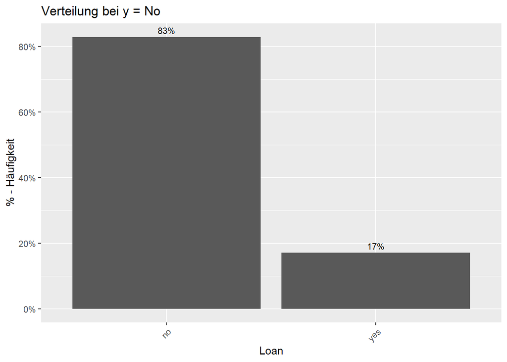

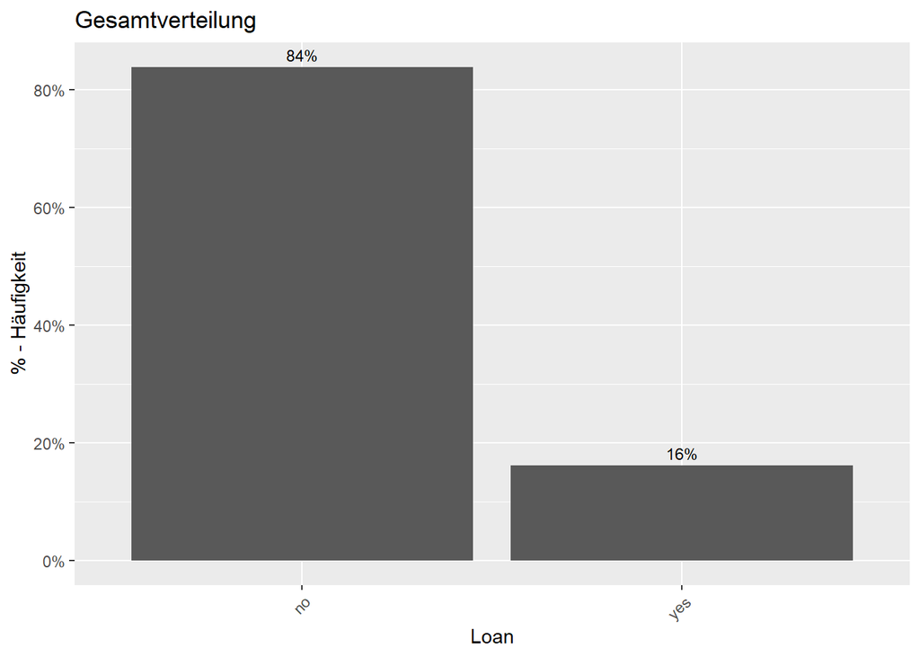

Sollte die Person bereits ein Persönliches Darlehnen haben, so ist es Wahrscheinlicher, dass sie kein weiteres Darlehnen aufnehmen wird.

### Contact-Variable

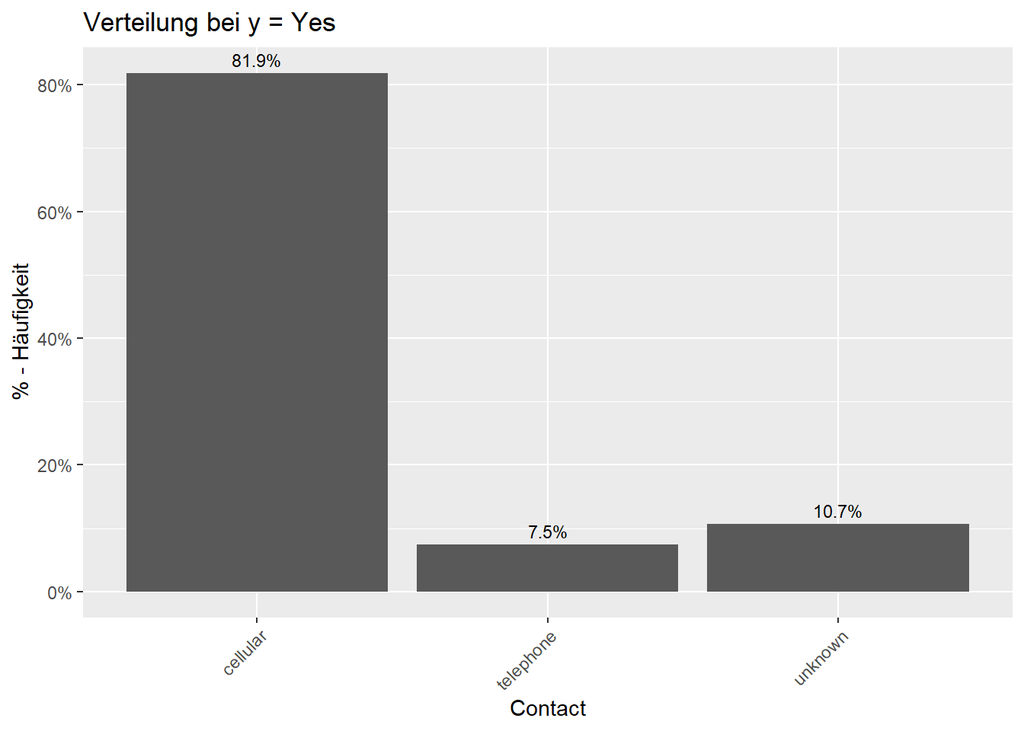

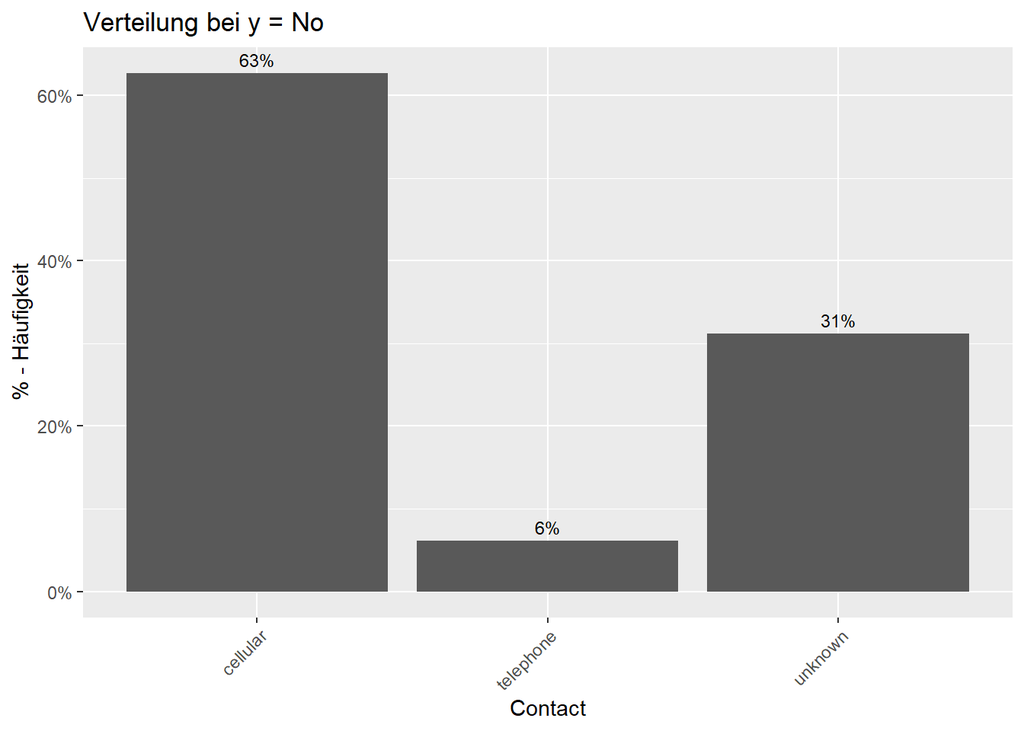

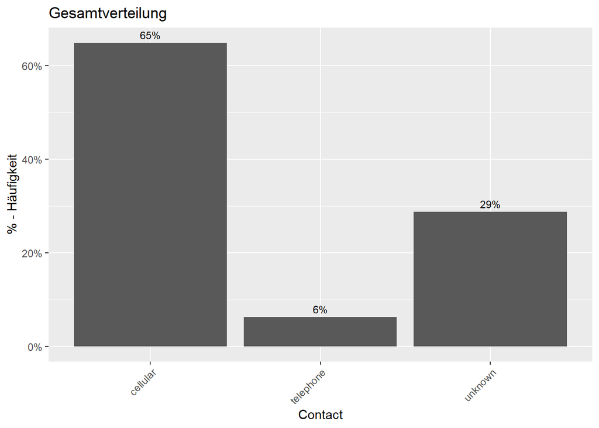

Wir haben hier wieder eine Weitere “unknown” Varibale. Diese hat einen sehr großen Anteil, jedoch ist dieser nicht übermäßig groß und wird NA-gesetzt.

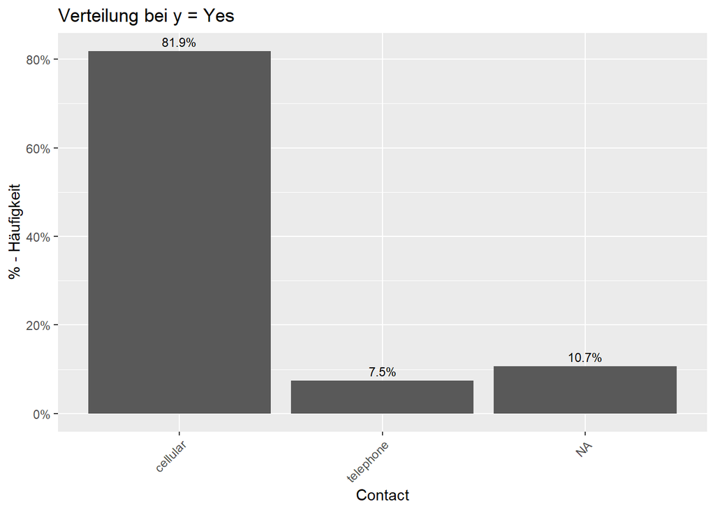

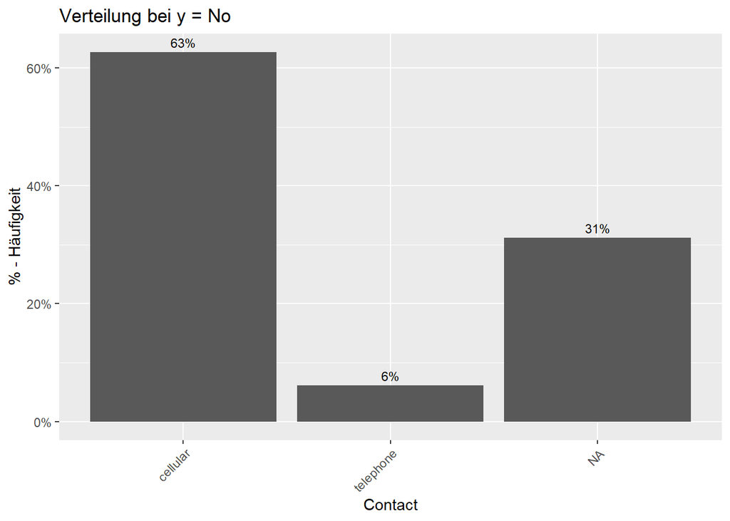

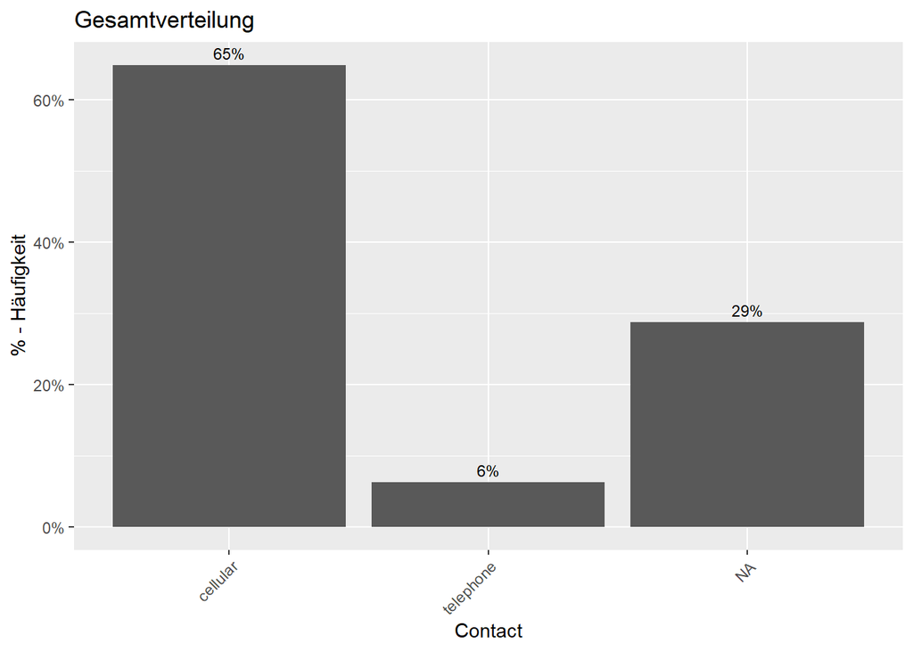

Der NA Anteil ist nun sehr groß.